# Project - California Quail in BC

Tyler Stevenson, Foster Lockerbie, Seamus Riordan-Short

18 April, 2025 11:55:45

## Loading Required Packages

```r
#load packages
library(spatstat)
library(sf)
library(rgbif)
```

## Import Data

```r
#occ_download_wait('0002650-250402121839773')
data <- occ_download_get('0002650-250402121839773') %>%
  occ_download_import()
```

```
## Download file size: 12.8 MB
```

```
## file exists & overwrite=FALSE, not overwriting...
```

```r
# Filter for only British Columbia records
bc_quail <- data[data$stateProvince %in%
                             c("British Columbia",
                               "British Columbia (BC)",
                               "British Columbia (Prov.)",
                               "Bc"), ]
```

## Convert Data to PPP

```r
load("BC_Covariates.Rda")

#Identify Class of Each Element
sapply(DATA, class)
```

```
##            Window         Elevation            Forest               HFI
## "SpatialPolygons"              "im"              "im"              "im"
##        Dist_Water
##              "im"
```

```r
# Convert quail data to sf object
quail_df <- st_as_sf(bc_quail, coords = c("decimalLongitude", "decimalLatitude"), crs = 4326, remove = FALSE)

# Remove duplicated coordinates
quail_df <- quail_df[!duplicated(st_coordinates(quail_df)), ]

# Convert window to sf
window_sf <- st_as_sf(DATA$Window)
```

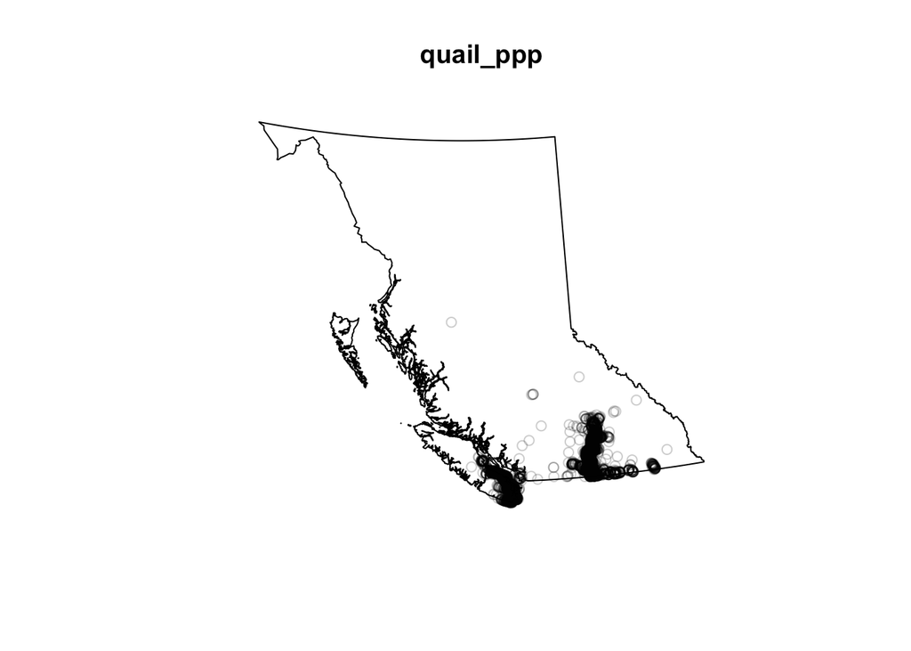

```r
# Ensure both quail coordinates and the window are in the same CRS
quail_df <- st_transform(quail_df, crs = st_crs(window_sf))

#Remove Points Outside the Window
inside_window <- st_intersects(quail_df, window_sf)
quail_df <- quail_df[sapply(inside_window, length) > 0, ]

# Extract the x and y coordinates of the quail
quail_coords <- st_coordinates(quail_df)

# Create the ppp object
quail_ppp <- ppp(x = quail_coords[, 1], y = quail_coords[, 2], window = as.owin(window_sf))


plot(quail_ppp)
```

## Determine Homogeneity

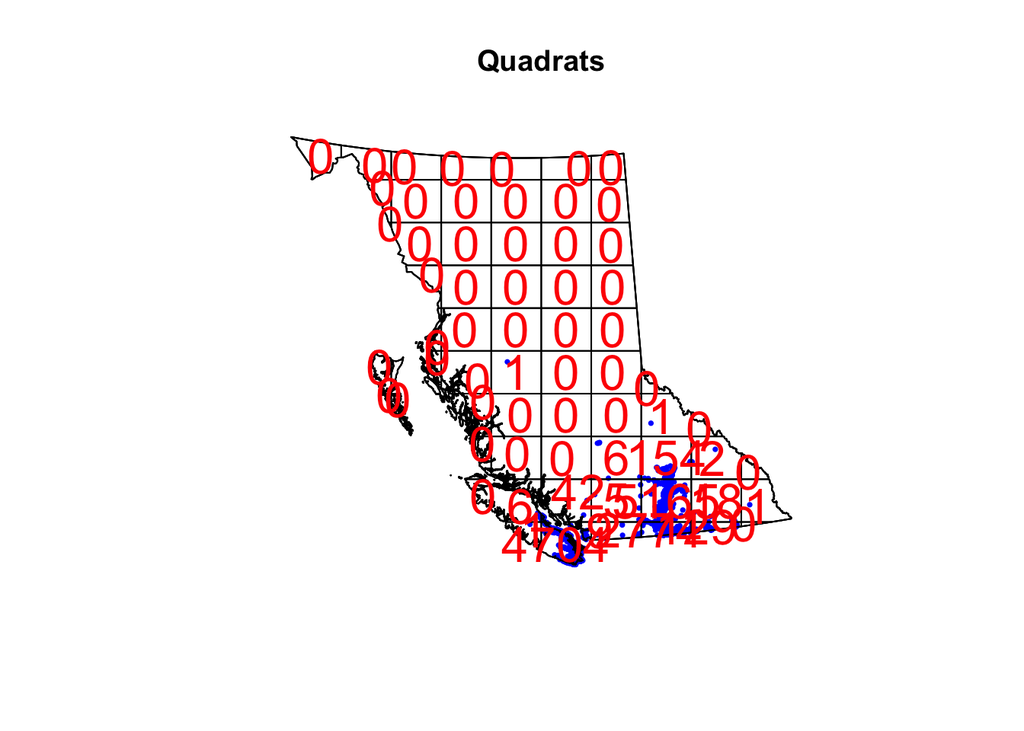

```r
# Split into quadrat and count points
Q <- quadratcount(quail_ppp, nx = 10, ny = 10)

#Plot the quadrats and points
plot(quail_ppp, pch=16,cex=.5, use.marks = F, cols= "blue", main = "Quadrats")
plot(Q, cex=2, col="red", add=T)
```

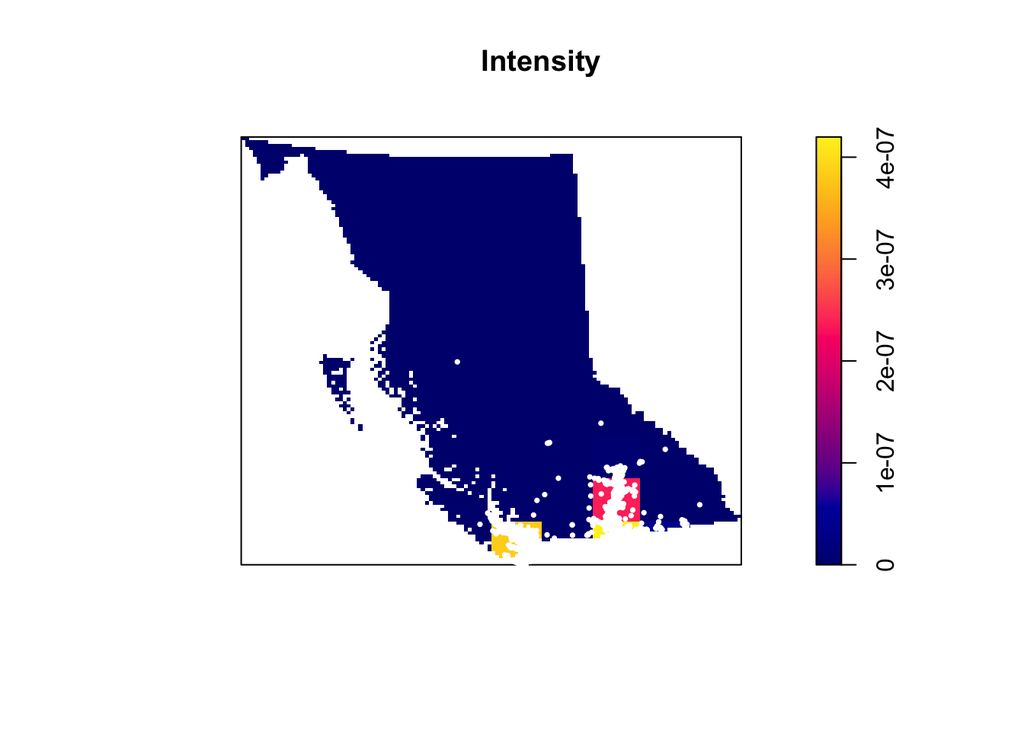

```r
#Plot the intensity
plot(intensity(Q, image =T), main="Intensity")
plot(quail_ppp, pch=16, cex=.5, use.marks = F, cols= "white",add=T)
```

```r
#Quadrat test of homogeneity
quadrat.test(Q)
```

```
##
##  Chi-squared test of CSR using quadrat counts
##
## data:
## X2 = 292527, df = 63, p-value < 2.2e-16
## alternative hypothesis: two.sided
##
## Quadrats: 64 tiles (irregular windows)
```

The small pvalue suggests that there is significant deviation from homogeneity. The quails tend to be clustered in some areas and others have none. The intensity varies in each quadrat suggesting that the intensity is not homogeneous and is spatially varying.

## Plotting Intensity

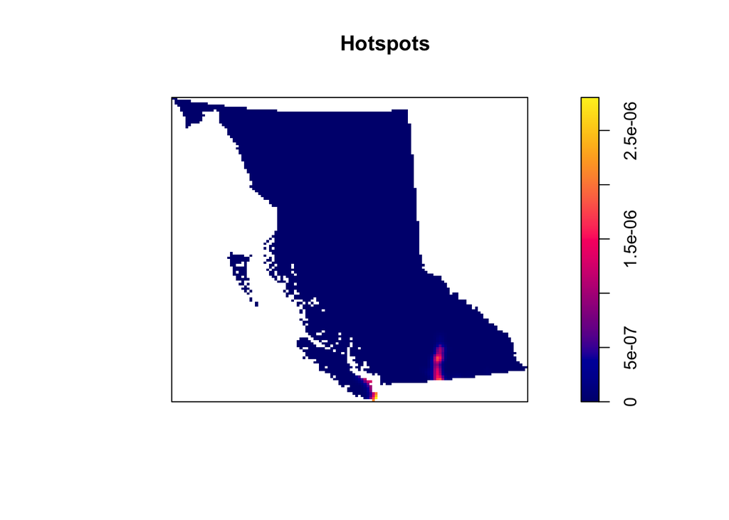

```r
#kernel estimation with likelihood cross validation bandwidth selection
lambda_u_hat <- density(quail_ppp, sigma = bw.ppl)
plot(lambda_u_hat, main="Hotspots")
```

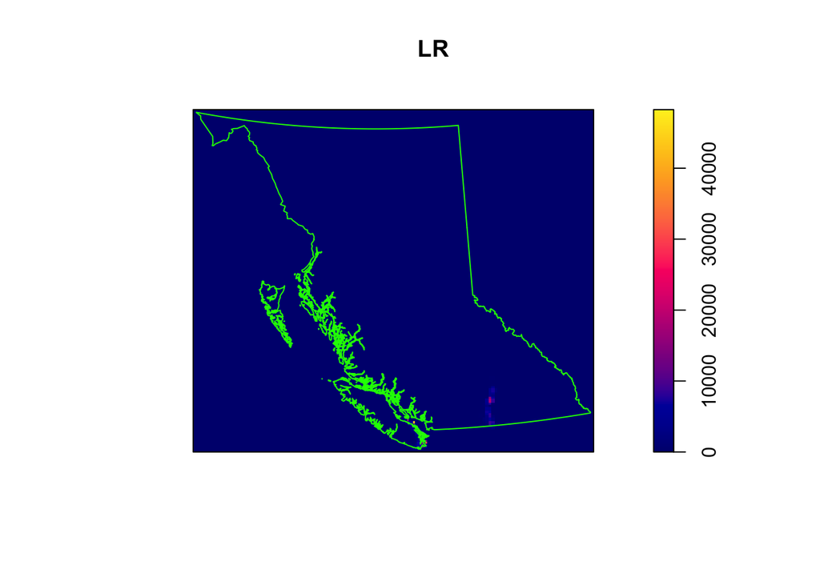

```r
# Estimate R
R <- bw.ppl(quail_ppp)

#Calculate test statistic
LR <- scanLRTS(quail_ppp, r = R)

#Plot the output
plot(LR)
plot(as.owin(window_sf),add=T,border="green")
```

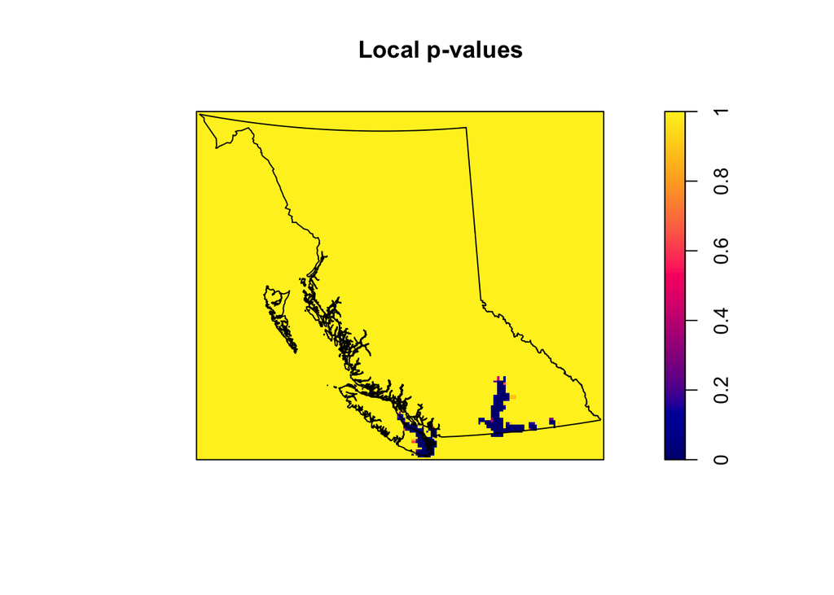

```r
#Compute local p-values
pvals <- eval.im(pchisq(LR,
                        df = 1,
                        lower.tail = FALSE))


#Plot the output
plot(pvals, main = "Local p-values")
plot(as.owin(window_sf),add=T)
```

The quail appear to be located in the southern interior and the southern coast of BC.

## Relationship Between Quail

```r
#Estimate a strictly positive density
lambda_pos <- density(quail_ppp, sigma=bw.ppl, positive=TRUE)

#Simulation envelope (with points drawn from the estimated intensity)
E_inhom <- envelope(quail_ppp,
                    Kinhom,
                    simulate = expression(rpoispp(lambda_pos)),
                    correction="border",
                    rank = 1,
                    nsim = 19,
                    fix.n = TRUE)
```

```
## Generating 19 simulations by evaluating expression  ...
## 1, 2, 3, 4, 5, 6, 7, 8, 9, 10, 11, 12, 13, 14, 15, 16, 17, 18,
## 19.
##
## Done.
```

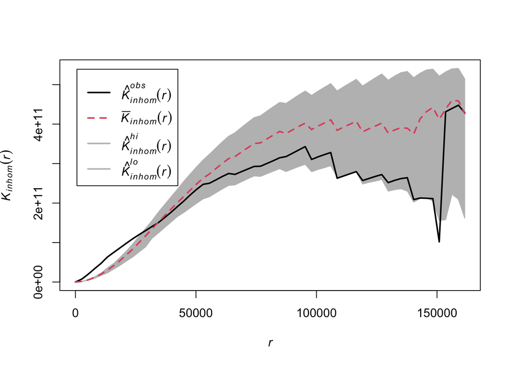

```r
# visualise the results
plot(E_inhom,
     main = "",
     lwd = 2)
```

```r
# Estimate g corrected for inhomogeneity
#g_inhom <- pcfinhom(quail_ppp)

#Simulation envelope (with points drawn from the estimated intensity)
#pcf_inhom <- envelope(quail_ppp,
                      #pcfinhom,
                      #simulate = expression(rpoispp(lambda_pos)),
                      #rank = 1,
                      #nsim = 19)

# visualise the results
#plot(pcf_inhom)
```

There appears to be clustering at lower distances. Which makes sense since quail tend to live in groups called coveys.

## Developing Model

### Covariates

```r
#Estimate Rho for elevation
rho_elev <- rhohat(quail_ppp, DATA$Elevation)
```

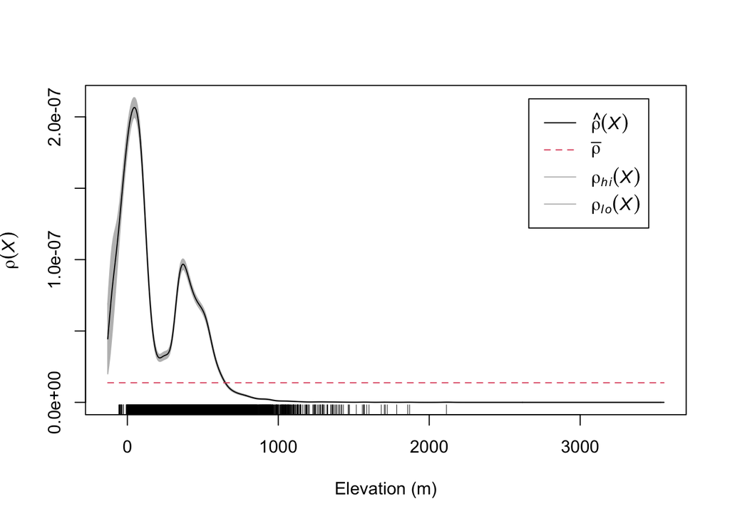

```r
plot(rho_elev,
     main = "",
     xlab = "Elevation (m)")
```

There appears to be a strong relationship with quail at lower elevations

```r
#Estimate Rho for forest cover
rho_for <- rhohat(quail_ppp, DATA$Forest)
```

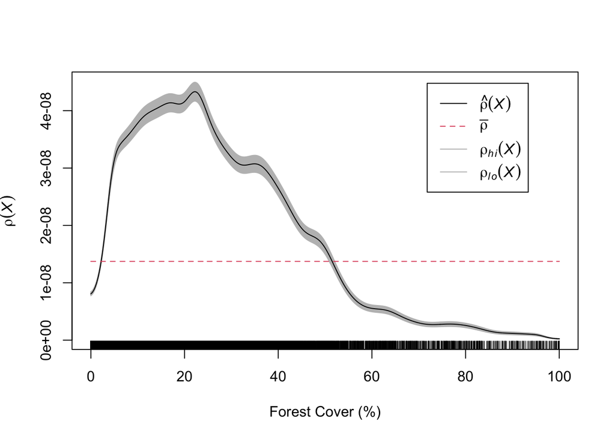

```r
plot(rho_for,
     main = "",
     xlab = "Forest Cover (%)")
```

There also appears to be a relationship with lower % of forest cover

```r
#Estimate Rho for HFI
rho_hfi <- rhohat(quail_ppp, DATA$HFI)
```

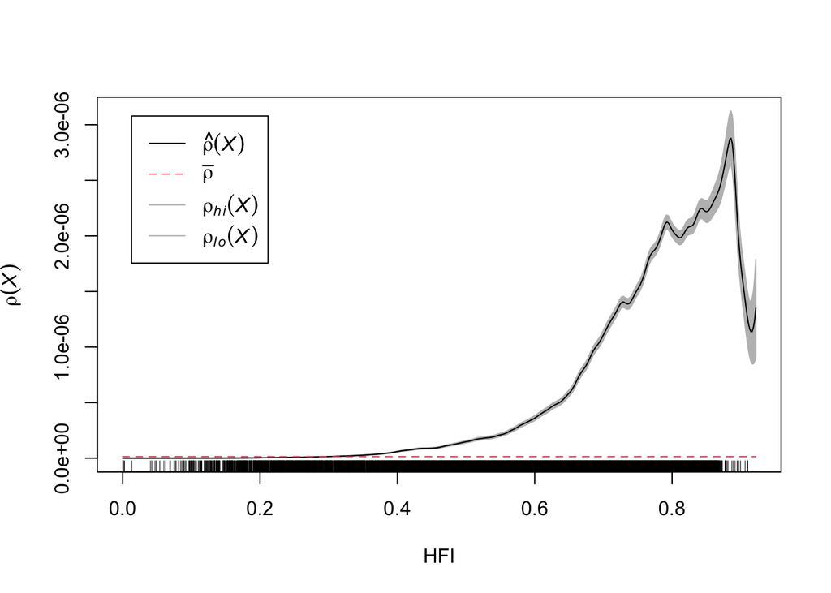

```r
plot(rho_hfi,
     main = "",
     xlab = "HFI")
```

There appears to be a relationship with higher levels of Human Footprint Index

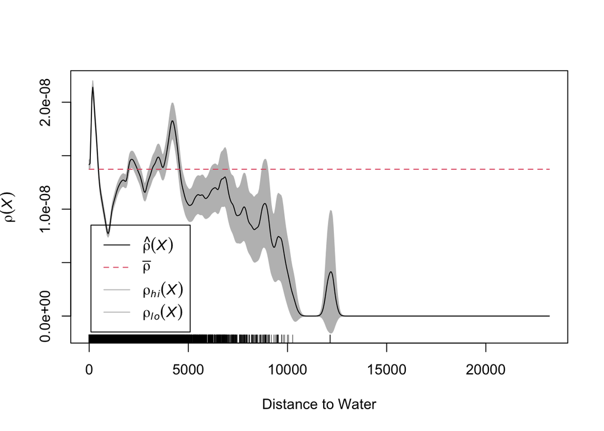

```r
#Estimate Rho for distance to water
rho_wat <- rhohat(quail_ppp, DATA$Dist_Water)

plot(rho_wat,
     main = "",
     xlab = "Distance to Water")
```

There appears to be a relationship with distance to water. The quail appear to be more present very close to the water.

### Collinearity

```r
#Check for collinearity
cor.im(DATA$Elevation, DATA$Forest, DATA$HFI, DATA$Dist_Water, use = "complete.obs")
```

```
##             ..1         ..2         ..3         ..4
## ..1  1.00000000 -0.26225376 -0.26625626 -0.03493453
## ..2 -0.26225376  1.00000000  0.06618592  0.04818598
## ..3 -0.26625626  0.06618592  1.00000000  0.13246899
## ..4 -0.03493453  0.04818598  0.13246899  1.00000000
```

There does not appear to be collinearity between the covariates

### Initial Model

Elevation, Forest Cover, HFI all appear to have a non-linear relationship. Distance to Water appears very sporadic but may be captured with linear

```r
# initial PPM model
fit <- ppm(quail_ppp ~ Elevation + I(Elevation^2) + Forest + I(Forest^2) + Dist_Water + HFI + I(HFI^2), data = DATA)
fit
```

```
## Nonstationary Poisson process
## Fitted to point pattern dataset 'quail_ppp'
##
## Log intensity:  ~Elevation + I(Elevation^2) + Forest + I(Forest^2) + Dist_Water
## + HFI + I(HFI^2)
##
## Fitted trend coefficients:
##    (Intercept)      Elevation I(Elevation^2)         Forest    I(Forest^2)
##  -2.154275e+01   4.288599e-03  -6.727676e-06   1.085611e-02  -1.820914e-04
##     Dist_Water            HFI       I(HFI^2)
##  -1.417567e-04   1.711722e+01  -9.021133e+00
##
##                     Estimate         S.E.       CI95.lo       CI95.hi Ztest
## (Intercept)    -2.154275e+01 7.019056e-02 -2.168032e+01 -2.140517e+01   ***
## Elevation       4.288599e-03 1.135247e-04  4.066095e-03  4.511104e-03   ***
## I(Elevation^2) -6.727676e-06 1.476392e-07 -7.017043e-06 -6.438308e-06   ***
## Forest          1.085611e-02 1.164139e-03  8.574436e-03  1.313778e-02   ***
## I(Forest^2)    -1.820914e-04 1.582147e-05 -2.131009e-04 -1.510819e-04   ***
## Dist_Water     -1.417567e-04 5.182248e-06 -1.519137e-04 -1.315997e-04   ***
## HFI             1.711722e+01 2.540221e-01  1.661934e+01  1.761509e+01   ***
## I(HFI^2)       -9.021133e+00 2.340794e-01 -9.479920e+00 -8.562346e+00   ***
##                       Zval
## (Intercept)    -306.917970
## Elevation        37.776793
## I(Elevation^2)  -45.568347
## Forest            9.325437
## I(Forest^2)     -11.509129
## Dist_Water      -27.354283
## HFI              67.384753
## I(HFI^2)        -38.538777
## Problem:
##  Values of the covariates 'Elevation', 'Forest', 'HFI' were NA or undefined at
## 0.26% (93 out of 36027) of the quadrature points
```

```r
#Fit the null model
fit_null <- ppm(quail_ppp ~ 1)
fit_null
```

```
## Stationary Poisson process
## Fitted to point pattern dataset 'quail_ppp'
## Intensity: 1.372827e-08
##              Estimate        S.E.   CI95.lo   CI95.hi Ztest     Zval
## log(lambda) -18.10381 0.008764515 -18.12099 -18.08663   *** -2065.58
```

```r
#AIC values
AIC(fit); AIC(fit_null)
```

```
## [1] 397828.6
```

```
## [1] 497388.8
```

```r
#Delta AIC
AIC(fit_null) - AIC(fit)
```

```
## [1] 99560.17
```

```r
#Likelihood ratio test
anova(fit_null, fit, test = "LRT")
```

[output not shown]

The AIC is lower and the likelihood ratio test is significant so the model we defined is a better fit than the null model.

```r
#Calculate the partial residuals as a function of elevation
par_res_elev <- parres(fit, "Elevation")
#Calculate the partial residuals as a function of forest cover
par_res_for <- parres(fit, "Forest")
#Calculate the partial residuals as a function of HFI
par_res_hfi <- parres(fit, "HFI")
#Calculate the partial residuals as a function of forest cover
par_res_wat <- parres(fit, "Dist_Water")
```

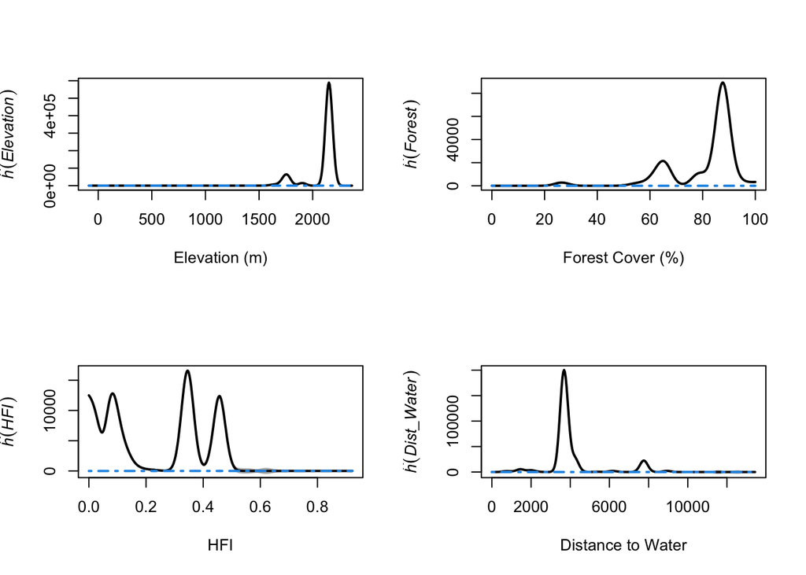

```r
#Side by side plotting
par(mfrow = c(2,2))
plot(par_res_elev,
     legend = FALSE,
     lwd = 2,
     main = "",
     xlab = "Elevation (m)")
plot(par_res_for,
     legend = FALSE,
     lwd = 2,
     main = "",
     xlab = "Forest Cover (%)")
plot(par_res_hfi,
     legend = FALSE,
     lwd = 2,
     main = "",
     xlab = "HFI")
plot(par_res_wat,
     legend = FALSE,
     lwd = 2,
     main = "",
     xlab = "Distance to Water")
```

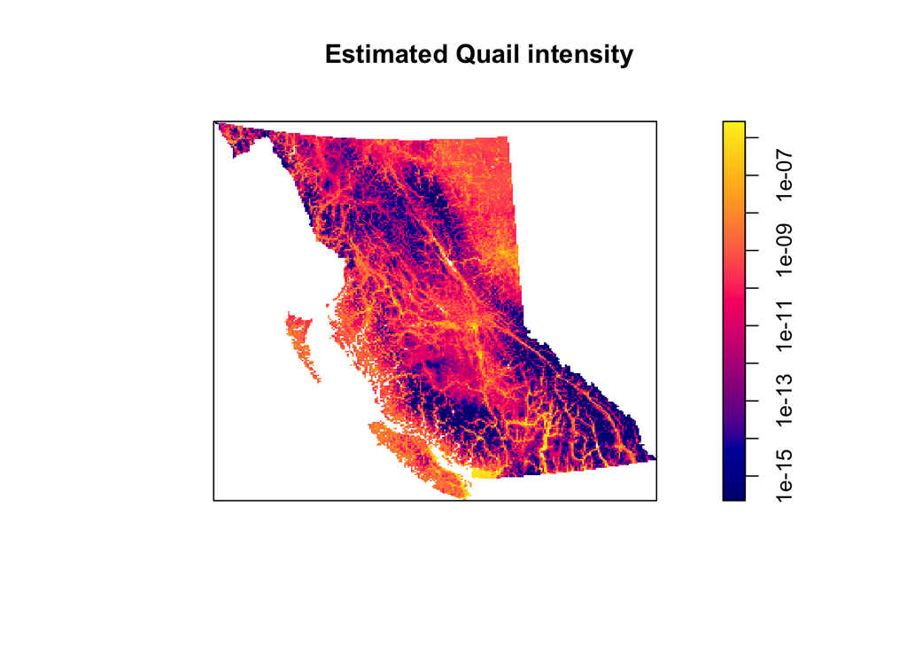

```r
#Plot the model predictions
plot(fit,
     se = FALSE,
     log = TRUE,
     superimpose = FALSE,
     main = "Estimated Quail intensity",
     n= 256)
```

### Model Adjustments with GAMS

```r
library(splines)

#Fit the PPP model
fit_smooth <- ppm(quail_ppp ~ bs(Elevation,8) + bs(Forest, 8) + bs(HFI, 8)+ Dist_Water, data = DATA, use.gam = TRUE)
fit_smooth
```

```
## Nonstationary Poisson process
## Fitted to point pattern dataset 'quail_ppp'
##
## Log intensity:  ~bs(Elevation, 8) + bs(Forest, 8) + bs(HFI, 8) + Dist_Water
##
## Fitted trend coefficients:
##       (Intercept) bs(Elevation, 8)1 bs(Elevation, 8)2 bs(Elevation, 8)3
##     -2.576652e+01      2.688610e+00      2.524867e+00      2.857603e+00
## bs(Elevation, 8)4 bs(Elevation, 8)5 bs(Elevation, 8)6 bs(Elevation, 8)7
##     -1.883928e-01      7.675531e-01     -7.605426e+00      1.413974e+01
## bs(Elevation, 8)8    bs(Forest, 8)1    bs(Forest, 8)2    bs(Forest, 8)3
##     -1.280932e+02     -2.286112e-01     -4.227615e-01      4.767835e-01
##    bs(Forest, 8)4    bs(Forest, 8)5    bs(Forest, 8)6    bs(Forest, 8)7
##     -2.893404e-01      4.064788e-01     -1.213582e+00     -2.392431e-02
##    bs(Forest, 8)8       bs(HFI, 8)1       bs(HFI, 8)2       bs(HFI, 8)3
##     -1.040482e+00      4.782449e-01      1.847235e+00      2.815407e+00
##       bs(HFI, 8)4       bs(HFI, 8)5       bs(HFI, 8)6       bs(HFI, 8)7
##      6.205006e+00      8.987489e+00      9.494601e+00      1.112959e+01
##       bs(HFI, 8)8        Dist_Water
##      9.634698e+00     -1.309893e-04
##
## For standard errors, type coef(summary(x))
## Problem:
##  Values of the covariates 'Elevation', 'Forest', 'HFI' were NA or undefined at
## 0.26% (93 out of 36027) of the quadrature points
```

```r
#Calculate the partial residuals as a function of elevation
par_res_elev <- parres(fit_smooth, "Elevation")
#Calculate the partial residuals as a function of forest cover
par_res_for <- parres(fit_smooth, "Forest")
#Calculate the partial residuals as a function of HFI
par_res_hfi <- parres(fit_smooth, "HFI")
#Calculate the partial residuals as a function of forest cover
par_res_wat <- parres(fit_smooth, "Dist_Water")
```

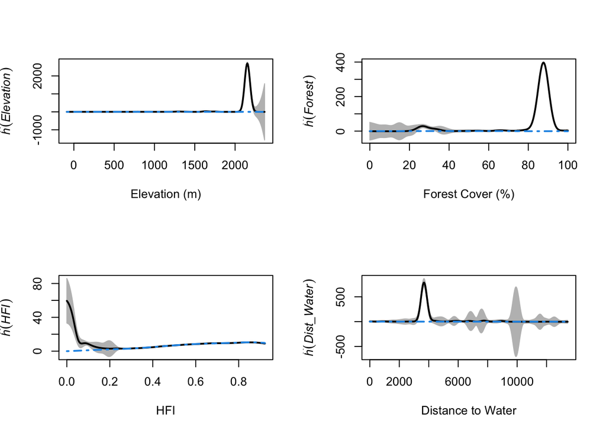

```r
#Side by side plotting
par(mfrow = c(2,2))
plot(par_res_elev,
     legend = FALSE,
     lwd = 2,
     main = "",
     xlab = "Elevation (m)")
plot(par_res_for,
     legend = FALSE,
     lwd = 2,
     main = "",
     xlab = "Forest Cover (%)")
plot(par_res_hfi,
     legend = FALSE,
     lwd = 2,
     main = "",
     xlab = "HFI")
plot(par_res_wat,
     legend = FALSE,
     lwd = 2,
     main = "",
     xlab = "Distance to Water")
```

```r
#AIC values
AIC(fit); AIC(fit_smooth)
```

```
## [1] 397828.6
```

```
## [1] 396048.3
```

```r
#Delta AIC
AIC(fit) - AIC(fit_smooth)
```

```
## [1] 1780.293
```

```r
#Likelihood ratio test
anova(fit, fit_smooth, test = "LRT")
```

```
## Analysis of Deviance Table
##
## Model 1: ~Elevation + I(Elevation^2) + Forest + I(Forest^2) + Dist_Water + HFI + I(HFI^2)     Poisson
## Model 2: ~bs(Elevation, 8) + bs(Forest, 8) + bs(HFI, 8) + Dist_Water      Poisson
##   Npar Df Deviance  Pr(>Chi)
## 1    8
## 2   26 18   1816.3 < 2.2e-16 ***
## ---
## Signif. codes:  0 '***' 0.001 '**' 0.01 '*' 0.05 '.' 0.1 ' ' 1
```

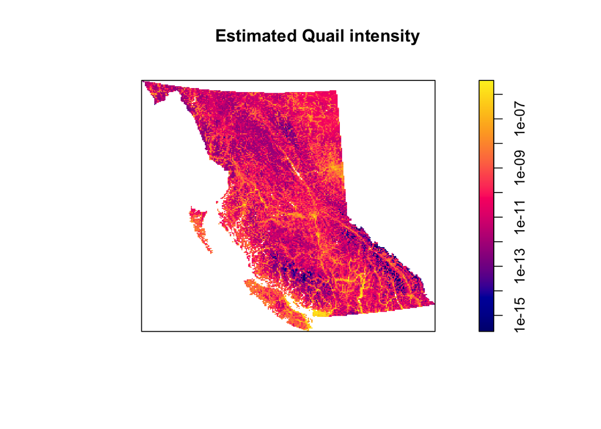

```r
#Plot the model predictions
plot(fit_smooth,
     se = FALSE,
     log = TRUE,
     superimpose = FALSE,
     main = "Estimated Quail intensity",
     n= 256)
```

### Model Adjustments with Cartesian Coordinates

```r
fit_cart <- ppm(quail_ppp ~ Elevation + I(Elevation^2) + Forest + I(Forest^2) + Dist_Water + HFI + I(HFI^2)+y, data = DATA)
fit_cart
```

```
## Nonstationary Poisson process
## Fitted to point pattern dataset 'quail_ppp'
##
## Log intensity:  ~Elevation + I(Elevation^2) + Forest + I(Forest^2) + Dist_Water
## + HFI + I(HFI^2) + y
##
## Fitted trend coefficients:
##    (Intercept)      Elevation I(Elevation^2)         Forest    I(Forest^2)
##  -1.336995e+01   8.825174e-03  -8.725086e-06  -5.575001e-03  -1.563629e-04
##     Dist_Water            HFI       I(HFI^2)              y
##  -2.162025e-04   1.204773e+01  -6.125180e+00  -1.299890e-05
##
##                     Estimate         S.E.       CI95.lo       CI95.hi Ztest
## (Intercept)    -1.336995e+01 1.034165e-01 -1.357265e+01 -1.316726e+01   ***
## Elevation       8.825174e-03 1.272664e-04  8.575737e-03  9.074612e-03   ***
## I(Elevation^2) -8.725086e-06 1.513053e-07 -9.021639e-06 -8.428533e-06   ***
## Forest         -5.575001e-03 1.205800e-03 -7.938327e-03 -3.211676e-03   ***
## I(Forest^2)    -1.563629e-04 1.669182e-05 -1.890782e-04 -1.236475e-04   ***
## Dist_Water     -2.162025e-04 5.604686e-06 -2.271875e-04 -2.052175e-04   ***
## HFI             1.204773e+01 2.637399e-01  1.153081e+01  1.256465e+01   ***
## I(HFI^2)       -6.125180e+00 2.400116e-01 -6.595594e+00 -5.654766e+00   ***
## y              -1.299890e-05 1.635763e-07 -1.331950e-05 -1.267830e-05   ***
##                       Zval
## (Intercept)    -129.282617
## Elevation        69.344108
## I(Elevation^2)  -57.665434
## Forest           -4.623486
## I(Forest^2)      -9.367638
## Dist_Water      -38.575312
## HFI              45.680351
## I(HFI^2)        -25.520347
## y               -79.466876
## Problem:
##  Values of the covariates 'Elevation', 'Forest', 'HFI' were NA or undefined at
## 0.26% (93 out of 36027) of the quadrature points
##
## *** Fitting algorithm for 'glm' did not converge ***
```

```r
#Calculate the partial residuals as a function of elevation
par_res_elev <- parres(fit_cart, "Elevation")
#Calculate the partial residuals as a function of forest cover
par_res_for <- parres(fit_cart, "Forest")
#Calculate the partial residuals as a function of HFI
par_res_hfi <- parres(fit_cart, "HFI")
#Calculate the partial residuals as a function of forest cover
par_res_wat <- parres(fit_cart, "Dist_Water")
#Calculate the partial residuals as a function of y
par_res_y <- parres(fit_cart, "y")
```

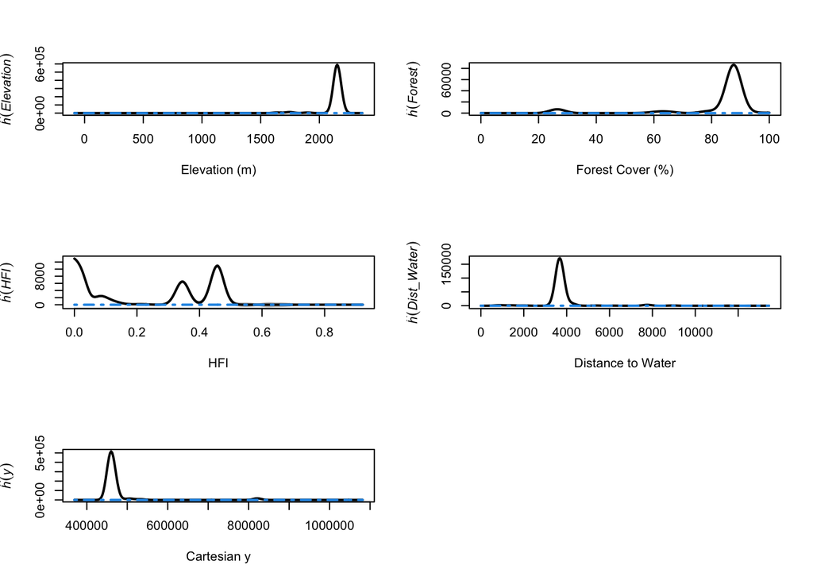

```r
#Side by side plotting
par(mfrow = c(3,2))
plot(par_res_elev,
     legend = FALSE,
     lwd = 2,
     main = "",
     xlab = "Elevation (m)")
plot(par_res_for,
     legend = FALSE,
     lwd = 2,
     main = "",
     xlab = "Forest Cover (%)")
plot(par_res_hfi,
     legend = FALSE,
     lwd = 2,
     main = "",
     xlab = "HFI")
plot(par_res_wat,
     legend = FALSE,
     lwd = 2,
     main = "",
     xlab = "Distance to Water")
plot(par_res_y,
     legend = FALSE,
     lwd = 2,
     main = "",
     xlab = "Cartesian y")
```

```r
#AIC values
AIC(fit); AIC(fit_cart)
```

```
## [1] 397828.6
```

```
## [1] 385305.2
```

```r
#Delta AIC
AIC(fit) - AIC(fit_cart)
```

```
## [1] 12523.42
```

```r
#Likelihood ratio test
anova(fit, fit_cart, test = "LRT")
```

```
## Analysis of Deviance Table
##
## Model 1: ~Elevation + I(Elevation^2) + Forest + I(Forest^2) + Dist_Water + HFI + I(HFI^2)     Poisson
## Model 2: ~Elevation + I(Elevation^2) + Forest + I(Forest^2) + Dist_Water + HFI + I(HFI^2) + y     Poisson
##   Npar Df Deviance  Pr(>Chi)
## 1    8
## 2    9  1    12525 < 2.2e-16 ***
## ---
## Signif. codes:  0 '***' 0.001 '**' 0.01 '*' 0.05 '.' 0.1 ' ' 1
```

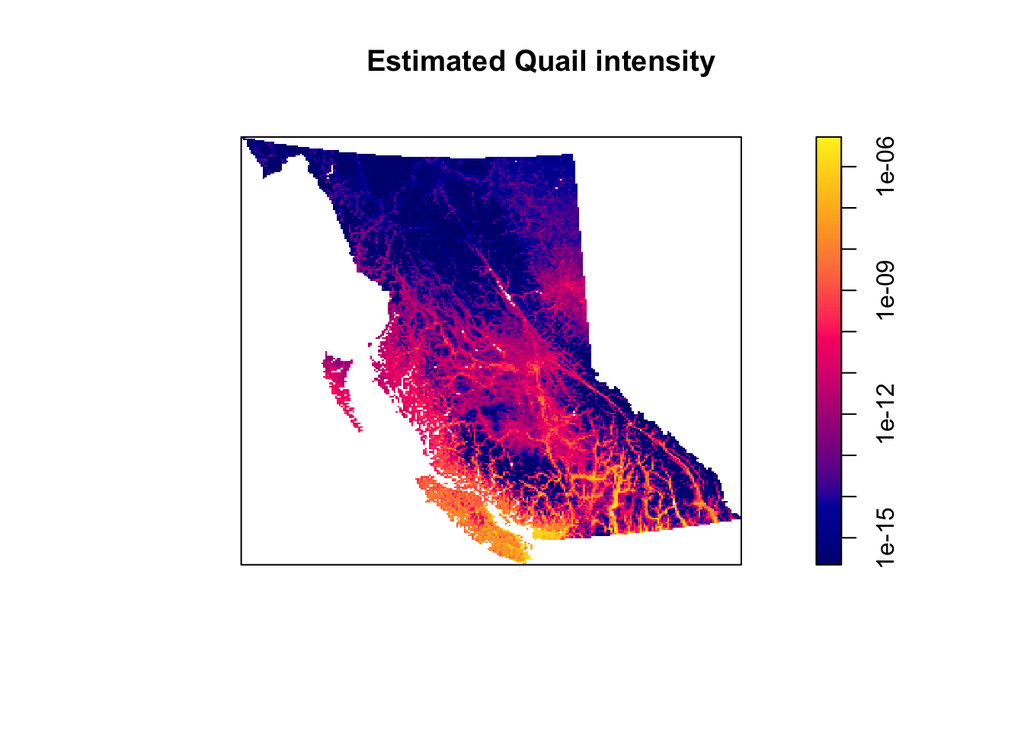

```r
#Plot the model predictions
plot(fit_cart,
     se = FALSE,
     log = TRUE,
     superimpose = FALSE,
     main = "Estimated Quail intensity",
     n= 256)
```